# Rmarkdown

Mario Cañizares and Federico Travascio

2025-01-12

## **PART I**

1. We introduce a method called Adaptive Conformal Inference (ACI) for constructing prediction sets in online learning contexts where the data distribution may vary over time. ACI addresses the limitation of traditional conformal inference methods that depend on the assumption of exchangeable data, often invalid in real-world scenarios.

Adaptive Conformal Inference builds upon standard conformal inference concepts:

Conformity Score: Measures how well a candidate value $y$ conforms to model predictions. Example for a regression model outputting $\hat{\mu}(X_t)$:

$$S(X_t, y) = |\hat{\mu}(X_t) - y|.$$

Prediction Sets: Using a calibration set $D_{\text{cal}} \subset \{(X_r, Y_r)\}{1 \leq r \leq t-1}$, compute the $(1-\alpha)$-quantile $\hat{Q}{1-\alpha}(S)$ of conformity scores:

$$\hat{C}t = \{ y : S(X_t, y) \leq
\hat{Q}{1-\alpha}(S)\}.$$

Quantile function: $\hat{Q}_t(p)$ based on the conformity scores can be expressed as:

$$\hat{Q}(p) := \inf \left\{ s : 0 \leq s
\leq 1 \ \middle| D_{\text{cal}} \right\}$$
$$\text{subject to } \frac{1}{|D_{\text{cal}}|}
\sum_{(X_r, Y_r) \in D_{\text{cal}}} {1}\{ S(X_r, Y_r) \leq s \}$$

In the presence of distributional shifts, the score function $S(\cdot)$ and the quantile function $\hat{Q}(\cdot)$ must be regularly re-estimated to align with the most recent observations.

At each time step $t$, a score function $S_t(\cdot)$ and a corresponding quantile function $\hat{Q}_t(\cdot)$ are estimated.

The realized miscoverage rate of the prediction set $\hat{C}_t(\alpha) := \{y : S_t(X_t, y) \leq \hat{Q}_t(1 - \alpha)\}$ is defined as:

$$M_t(\alpha) := P(S_t(X_t, Y_t) > \hat{Q}_t(1
- \alpha)),$$
where the probability is over the test point $(X_t, Y_t)$ and the data used to estimate $S_t(\cdot)$ and $\hat{Q}_t(\cdot)$.

Due to the non-stationarity of the distribution, $M_t(\alpha)$ will not necessarily equal or even approximate $\alpha$.

It is hypothesized that if the conformity scores used to estimate $\hat{Q}_t(\cdot)$ cover most of the distribution of $S_t(X_t, Y_t)$, then there may exist an alternative value $\alpha_t^* \in [0, 1]$ such that $M_t(\alpha_t^*) \approx \alpha$.

To calibrate this, a simple online update is used. It examines the empirical frequency of miscoverage in previous prediction sets and decreases (or increases) the estimate of $\alpha_t^*$ if the prediction sets have historically undercovered (or overcovered) $Y_t$.

The online update rule is:

$$\alpha_{t+1}
:= \alpha_t + \gamma(\alpha - \text{err}_t),$$
where $\alpha_1$ is the initial estimate, $\gamma$ is a step size parameter, and $\text{err}_t$ is an indicator that equals 1 if $Y_t \notin \hat{C}_t(\alpha_t)$ and 0 otherwise. adjusts the confidence level $\alpha_t$ based on the miscoverage. If there was miscoverage (i.e., $\text{err}_t = 1$), the confidence level is increased (by $\gamma \times (\alpha - 1)$), to make the prediction set wider and more likely to include the true value in future predictions. If no miscoverage occurred (i.e., $\text{err}_t = 0$), the confidence level is adjusted to maintain or refine the prediction.

In summary, ACI adapts conformal inference to distributional shifts by dynamically calibrating a single parameter $\alpha_t^*$, which controls the coverage level of the prediction set. The online update relies on the historical prediction errors to maintain the desired coverage over time.

A second equation using a weighted average of past errors is also introduced. It smoothes out fluctuations in the coverage results, leading to a more stable update of alpha (t).

$$\alpha_{t+1} = \alpha_t + \gamma \left( \alpha - \sum_{s=1}^{t} w_s
\cdot \text{err}_s \right)$$

```r
library(quantmod)
library(quantreg)
library(rugarch)
library(dplyr)
# B.1:

### GARCH(1,1) - SIMPLE SCORES - STANDARD CP
garchCF <- function(returns, alpha = 0.05, lookback = 1250, garchP = 1, garchQ = 1, startUp = 100, verbose = FALSE) {
  myT <- length(returns)
  T0 <- max(startUp, lookback)

  # Specification of the GARCH(1,1) model
  garchSpec <- ugarchspec(
    mean.model = list(armaOrder = c(0, 0), include.mean = FALSE),
    variance.model = list(model = "sGARCH", garchOrder = c(garchP, garchQ)),
    distribution.model = "norm"
  )

  # Initialization of storage variables
  errSeq_garch_simple <- rep(0, myT - T0 + 1)
  scores_garch_simple <- rep(0, myT - T0 + 1)

  for (t in T0:myT) {
    if (verbose) {
      print(t)
    }

    # Fit the GARCH model and compute the forecast of future variance
    garchFit <- ugarchfit(garchSpec, returns[(t - lookback + 1):(t - 1)], solver = "hybrid")
    sigmaNext <- sigma(ugarchforecast(garchFit, n.ahead = 1))^2  # Variance forecast

    # Compute the unnormalized conformity score
    scores_garch_simple[t - T0 + 1] <- abs(returns[t]^2 - sigmaNext)

    # Get recent conformity scores to calculate the error
    recentScores <- scores_garch_simple[max(t - T0 + 1 - lookback + 1, 1):(t - T0)]

    # Compute the error based on the fixed alpha value
    errSeq_garch_simple[t - T0 + 1] <- as.numeric(scores_garch_simple[t - T0 + 1] > quantile(recentScores, 1 - alpha))

    if (t %% 100 == 0) {
      print(sprintf("Done %g steps", t))
    }
  }

  return(list(errSeq = errSeq_garch_simple, scores = scores_garch_simple))
}
```

**GARCH(1,1) Conformity-Score Function Explanation**

The `garchCF` function is designed to assess the accuracy of a GARCH(1,1) volatility forecast for a given series of financial returns. At each step in time, it fits a GARCH(1,1) model over a rolling window of recent returns, obtains a one-step-ahead forecast of the variance, and measures how far the observed squared return deviates from that forecast. This deviation is called the “conformity score.”

The function then compares the new score against a historical distribution of past scores to see if it exceeds a chosen quantile (determined by $\alpha$). If it does, it registers an error, indicating that the most recent forecast deviated from observations more than usual. This helps identify whether the model is underestimating or overestimating volatility in real time.

```r
### EGARCH - SIMPLE SCORES - STANDARD CP
EgarchCF <- function(returns, alpha = 0.05, lookback = 1250, garchP = 1, garchQ = 1, startUp = 100, verbose = FALSE) {
  myT <- length(returns)
  T0 <- max(startUp, lookback)

  # Specification of the EGARCH(1,1) model
  garchSpec <- ugarchspec(
    mean.model = list(armaOrder = c(0, 0), include.mean = FALSE),
    variance.model = list(model = "eGARCH", garchOrder = c(garchP, garchQ)),
    distribution.model = "norm"
  )

  # Initialization of storage variables
  errSeq_egarch_simple <- rep(0, myT - T0 + 1)
  scores_egarch_simple <- rep(0, myT - T0 + 1)

  for (t in T0:myT) {
    if (verbose) {
      print(t)
    }

    # Fit the EGARCH model and compute the forecast of future variance
    garchFit <- ugarchfit(garchSpec, returns[(t - lookback + 1):(t - 1)], solver = "hybrid")
    sigmaNext <- sigma(ugarchforecast(garchFit, n.ahead = 1))^2  # Variance forecast

    # Compute the unnormalized conformity score
    scores_egarch_simple[t - T0 + 1] <- abs(returns[t]^2 - sigmaNext)

    # Get recent conformity scores to calculate the error
    recentScores <- scores_egarch_simple[max(t - T0 + 1 - lookback + 1, 1):(t - T0)]

    # Compute the error based on the fixed alpha value
    errSeq_egarch_simple[t - T0 + 1] <- as.numeric(scores_egarch_simple[t - T0 + 1] > quantile(recentScores, 1 - alpha))

    if (t %% 100 == 0) {
      print(sprintf("Done %g steps", t))
    }
  }

  return(list(errSeq = errSeq_egarch_simple, scores = scores_egarch_simple))
}
```

**EGARCH(1,1) Conformity-Score Function Explanation**

The `EgarchCF` function measures the performance of an EGARCH(1,1) volatility forecast for a series of financial returns. At each iteration, it fits an EGARCH(1,1) model on a rolling window of past returns, generates a one-step-ahead variance forecast, and calculates how far the observed squared return deviates from that forecast. This deviation is recorded as a “conformity score.”

It then compares the new conformity score to a historical distribution of recent scores. If the new score exceeds the chosen quantile $(1 - \alpha)$, an error is recorded to indicate that the most recent forecast is unusually inaccurate. This procedure helps identify periods when the model underestimates or overestimates volatility.

```r
### GARCH(1,1) - NORMALIZED SCORES
NormgarchCF <- function(returns, alpha = 0.05, lookback = 1250, garchP = 1, garchQ = 1, startUp = 100, verbose = FALSE) {
  myT <- length(returns)
  T0 <- max(startUp, lookback)

  # Specification of the GARCH(1,1) model
  garchSpec <- ugarchspec(
    mean.model = list(armaOrder = c(0, 0), include.mean = FALSE),
    variance.model = list(model = "sGARCH", garchOrder = c(garchP, garchQ)),
    distribution.model = "norm"
  )

  # Initialization of storage variables
  errSeq_garch_norm <- rep(0, myT - T0 + 1)
  scores_garch_norm <- rep(0, myT - T0 + 1)

  for (t in T0:myT) {
    if (verbose) {
      print(t)
    }

    # Fit the GARCH model and compute the forecast of future variance
    garchFit <- ugarchfit(garchSpec, returns[(t - lookback + 1):(t - 1)], solver = "hybrid")
    sigmaNext <- sigma(ugarchforecast(garchFit, n.ahead = 1))^2  # Variance forecast

    # Compute the normalized conformity score
    scores_garch_norm[t - T0 + 1] <- abs(returns[t]^2 - sigmaNext) / sigmaNext

    # Get recent conformity scores to calculate the error
    recentScores <- scores_garch_norm[max(t - T0 + 1 - lookback + 1, 1):(t - T0)]

    # Compute the error based on the fixed alpha value
    errSeq_garch_norm[t - T0 + 1] <- as.numeric(scores_garch_norm[t - T0 + 1] > quantile(recentScores, 1 - alpha))

    if (t %% 100 == 0) {
      print(sprintf("Done %g steps", t))
    }
  }

  return(list(errSeq = errSeq_garch_norm, scores = scores_garch_norm))
}
```

**GARCH(1,1) with Normalized Scores Function Explanation**

The `NormgarchCF` function evaluates the forecasting performance of a GARCH(1,1) volatility model by calculating **normalized conformity scores**, which are adjusted for the forecasted variance. This provides a scale-invariant measure of how much the observed squared return deviates from the predicted variance. By normalizing, it accounts for the varying levels of volatility across time.

At each step, the function fits a GARCH(1,1) model using a rolling window of past returns, forecasts the variance for the next time step, and calculates the normalized conformity score as the absolute difference between the squared return and forecasted variance, divided by the forecasted variance. These scores are compared against a historical quantile threshold to flag unusually large deviations.

### Purpose:

This function provides a more robust and scale-adjusted measure of forecast accuracy, particularly useful when volatility levels vary significantly over time. The normalization ensures comparability across periods, making the error detection more reliable for dynamic financial data.

In essence, `NormgarchCF` helps monitor and evaluate the performance of GARCH forecasts by identifying periods where predictions deviate significantly, even after accounting for volatility scaling.

```r
### EGARCH - NORMALIZED SCORES
NormEgarchCF <- function(returns, alpha = 0.05, lookback = 1250, garchP = 1, garchQ = 1, startUp = 100, verbose = FALSE) {
  myT <- length(returns)
  T0 <- max(startUp, lookback)

  # Specification of the EGARCH(1,1) model
  garchSpec <- ugarchspec(
    mean.model = list(armaOrder = c(0, 0), include.mean = FALSE),
    variance.model = list(model = "eGARCH", garchOrder = c(garchP, garchQ)),
    distribution.model = "norm"
  )

  # Initialization of storage variables
  errSeq_egarch_norm <- rep(0, myT - T0 + 1)
  scores_egarch_norm <- rep(0, myT - T0 + 1)

  for (t in T0:myT) {
    if (verbose) {
      print(t)
    }

    # Fit the EGARCH model and compute the forecast of future variance
    garchFit <- ugarchfit(garchSpec, returns[(t - lookback + 1):(t - 1)], solver = "hybrid")
    sigmaNext <- sigma(ugarchforecast(garchFit, n.ahead = 1))^2  # Variance forecast

    # Compute the normalized conformity score
    scores_egarch_norm[t - T0 + 1] <- abs(returns[t]^2 - sigmaNext) / sigmaNext

    # Get recent conformity scores to calculate the error
    recentScores <- scores_egarch_norm[max(t - T0 + 1 - lookback + 1, 1):(t - T0)]

    # Compute the error based on the fixed alpha value
    errSeq_egarch_norm[t - T0 + 1] <- as.numeric(scores_egarch_norm[t - T0 + 1] > quantile(recentScores, 1 - alpha))

    if (t %% 100 == 0) {
      print(sprintf("Done %g steps", t))
    }
  }

  return(list(errSeq = errSeq_egarch_norm, scores = scores_egarch_norm))
}
```

**EGARCH(1,1) with Normalized Scores Function Explanation**

The `NormEgarchCF` function is designed to evaluate the forecasting accuracy of an EGARCH(1,1) model by calculating **normalized conformity scores**, which adjust the forecast error for the predicted variance. This normalization ensures the scores are scale-invariant, allowing for consistent evaluation regardless of volatility levels.

At each step, the function fits an EGARCH(1,1) model on a rolling window of past returns, generates a one-step-ahead forecast of variance, and calculates the normalized conformity score as the absolute difference between the observed squared return and the forecasted variance, divided by the forecasted variance. The function then compares this score to a quantile threshold derived from recent scores to detect unusually large forecast deviations.

### Purpose:

The function is tailored for evaluating the accuracy and reliability of EGARCH(1,1) forecasts. By normalizing the conformity scores, it accounts for variability in forecasted volatility, enabling more robust detection of underperformance or miscalibration in the model. This approach is particularly useful in scenarios where volatility dynamics are highly variable over time.

In essence, `NormEgarchCF` identifies periods where EGARCH-based variance forecasts deviate significantly from observed values after normalization, providing insights into the model’s real-time performance.

```r
#B.2:
#Adaptive Garch Simple
AdaptivegarchCF <- function(returns, alpha = 0.05, gamma = 0.001, lookback = 1250, garchP = 1, garchQ = 1, startUp = 100, verbose = FALSE) {
  myT <- length(returns)
  T0 <- max(startUp, lookback)

  # Specification of the GARCH(1,1) model
  garchSpec <- ugarchspec(
    mean.model = list(armaOrder = c(0, 0), include.mean = FALSE),
    variance.model = list(model = "sGARCH", garchOrder = c(garchP, garchQ)),
    distribution.model = "norm"
  )

  # Initialization of storage variables
  errSeq_adaptive_garch_simple <- rep(0, myT - T0 + 1)
  alphaSequence_adaptive_garch_simple <- rep(alpha, myT - T0 + 1)
  scores_adaptive_garch_simple <- rep(0, myT - T0 + 1)

  alphat <- alpha  # Initialize adaptive alpha

  for (t in T0:myT) {
    if (verbose) {
      print(t)
    }

    # Fit the GARCH model and calculate the forecasted future variance
    garchFit <- ugarchfit(garchSpec, returns[(t - lookback + 1):(t - 1)], solver = "hybrid")
    sigmaNext <- sigma(ugarchforecast(garchFit, n.ahead = 1))^2  # Forecasted variance

    # Calculate the simple conformity score (not normalized)
    scores_adaptive_garch_simple[t - T0 + 1] <- abs(returns[t]^2 - sigmaNext)

    # Get recent conformity scores to calculate the error
    recentScores <- scores_adaptive_garch_simple[max(t - T0 + 1 - lookback + 1, 1):(t - T0)]

    # Calculate the error for the adaptive method
    errSeq_adaptive_garch_simple[t - T0 + 1] <- as.numeric(scores_adaptive_garch_simple[t - T0 + 1] > quantile(recentScores, 1 - alphat))

    # Update alphat ("Simple" method)
    alphaSequence_adaptive_garch_simple[t - T0 + 1] <- alphat
    alphat <- pmin(pmax(alphat + gamma * (alpha - errSeq_adaptive_garch_simple[t - T0 + 1]), 0), 1)

    if (t %% 100 == 0) {
      print(sprintf("Done %g steps", t))
    }
  }

  return(list(alphaSequence = alphaSequence_adaptive_garch_simple, errSeq = errSeq_adaptive_garch_simple, scores = scores_adaptive_garch_simple))
}
```

GARCH(1,1) - Simple scores - Adaptive CP: The function above implements an adaptive conformal prediction (CP) strategy using a GARCH(1,1) model with simple scores. Unlike standard CP methods, it considers the miscoverage threshold (alpha) based on recent errors. The threshold adjustment is governed by the adaptation rate (gamma). In terms of lookback, it is now utilized not only for model fitting but also for threshold calculations. Additionally, there is a new parameter, gamma, which controls how quickly alpha adjusts to recent prediction errors. The output differs as it returns not only the usual errSeq and scores but also the alphaSequence, representing the adjusted alpha over time.

```r
#Adaptive Egarch Simple
AdaptiveEgarchCF <- function(returns, alpha = 0.05, gamma = 0.001, lookback = 1250, garchP = 1, garchQ = 1, startUp = 100, verbose = FALSE) {
  myT <- length(returns)
  T0 <- max(startUp, lookback)

  # Specification of the EGARCH(1,1) model
  garchSpec <- ugarchspec(
    mean.model = list(armaOrder = c(0, 0), include.mean = FALSE),
    variance.model = list(model = "eGARCH", garchOrder = c(garchP, garchQ)),
    distribution.model = "norm"
  )

  # Initialization of storage variables
  errSeq_adaptive_egarch_simple <- rep(0, myT - T0 + 1)
  alphaSequence_adaptive_egarch_simple <- rep(alpha, myT - T0 + 1)
  scores_adaptive_egarch_simple <- rep(0, myT - T0 + 1)

  alphat <- alpha  # Initialize adaptive alpha

  for (t in T0:myT) {
    if (verbose) {
      print(t)
    }

    # Fit the EGARCH model and calculate the forecasted future variance
    garchFit <- ugarchfit(garchSpec, returns[(t - lookback + 1):(t - 1)], solver = "hybrid")
    sigmaNext <- sigma(ugarchforecast(garchFit, n.ahead = 1))^2  # Forecasted variance

    # Calculate the simple conformity score (not normalized)
    scores_adaptive_egarch_simple[t - T0 + 1] <- abs(returns[t]^2 - sigmaNext)

    # Get recent conformity scores to calculate the error
    recentScores <- scores_adaptive_egarch_simple[max(t - T0 + 1 - lookback + 1, 1):(t - T0)]

    # Calculate the error for the adaptive method
    errSeq_adaptive_egarch_simple[t - T0 + 1] <- as.numeric(scores_adaptive_egarch_simple[t - T0 + 1] > quantile(recentScores, 1 - alphat))

    # Update alphat ("Simple" method)
    alphaSequence_adaptive_egarch_simple[t - T0 + 1] <- alphat
    alphat <- pmin(pmax(alphat + gamma * (alpha - errSeq_adaptive_egarch_simple[t - T0 + 1]), 0), 1)

    if (t %% 100 == 0) {
      print(sprintf("Done %g steps", t))
    }
  }

  return(list(alphaSequence = alphaSequence_adaptive_egarch_simple, errSeq = errSeq_adaptive_egarch_simple, scores = scores_adaptive_egarch_simple))
}
```

EGARCH - Simple scores - Adaptive CP: This function is similar to the previous one, but instead of utilizing the GARCH(1,1) model, it applies the EGARCH(1,1) model. Unlike GARCH, the EGARCH model considers leverage effects, making it better suited to capture asymmetries in financial data.

```r
#Adaptive Norm Garch Simple
AdaptiveNormgarchCF <- function(returns, alpha = 0.05, gamma = 0.001, lookback = 1250, garchP = 1, garchQ = 1, startUp = 100, verbose = FALSE) {
  myT <- length(returns)
  T0 <- max(startUp, lookback)

  # Specification of the GARCH(1,1) model
  garchSpec <- ugarchspec(
    mean.model = list(armaOrder = c(0, 0), include.mean = FALSE),
    variance.model = list(model = "sGARCH", garchOrder = c(garchP, garchQ)),
    distribution.model = "norm"
  )

  # Initialization of storage variables
  errSeq_adaptive_norm_garch_simple <- rep(0, myT - T0 + 1)
  alphaSequence_adaptive_norm_garch_simple <- rep(alpha, myT - T0 + 1)
  scores_adaptive_norm_garch_simple <- rep(0, myT - T0 + 1)

  alphat <- alpha  # Initialize adaptive alpha

  for (t in T0:myT) {
    if (verbose) {
      print(t)
    }

    # Fit the GARCH model and calculate the forecasted future variance
    garchFit <- ugarchfit(garchSpec, returns[(t - lookback + 1):(t - 1)], solver = "hybrid")
    sigmaNext <- sigma(ugarchforecast(garchFit, n.ahead = 1))^2  # Forecasted variance

    # Calculate the normalized conformity score
    scores_adaptive_norm_garch_simple[t - T0 + 1] <- abs(returns[t]^2 - sigmaNext) / sigmaNext

    # Get recent conformity scores to calculate the error
    recentScores <- scores_adaptive_norm_garch_simple[max(t - T0 + 1 - lookback + 1, 1):(t - T0)]

    # Calculate the error for the adaptive method
    errSeq_adaptive_norm_garch_simple[t - T0 + 1] <- as.numeric(scores_adaptive_norm_garch_simple[t - T0 + 1] > quantile(recentScores, 1 - alphat))

    # Update alphat ("Simple" method)
    alphaSequence_adaptive_norm_garch_simple[t - T0 + 1] <- alphat
    alphat <- pmin(pmax(alphat + gamma * (alpha - errSeq_adaptive_norm_garch_simple[t - T0 + 1]), 0), 1)

    if (t %% 100 == 0) {
      print(sprintf("Done %g steps", t))
    }
  }

  return(list(alphaSequence = alphaSequence_adaptive_norm_garch_simple, errSeq = errSeq_adaptive_norm_garch_simple, scores = scores_adaptive_norm_garch_simple))
}
```

GARCH(1,1) - Normalized scores - Adaptive CP: This function once again implements an adaptive conformal prediction (CP) strategy, this time using the GARCH(1,1) model with normalized scores. Unlike simple scores, normalized scores are derived by dividing the residuals by the forecasted variance, which provides a scale-invariant measure of conformity, enhancing robustness and making the prediction more reliable across varying data scales.

```r
#Adaptive Norm Egarch Simple
AdaptiveNormEgarchCF <- function(returns, alpha = 0.05, gamma = 0.001, lookback = 1250, garchP = 1, garchQ = 1, startUp = 100, verbose = FALSE) {
  myT <- length(returns)
  T0 <- max(startUp, lookback)

  # Specification of the EGARCH(1,1) model
  garchSpec <- ugarchspec(
    mean.model = list(armaOrder = c(0, 0), include.mean = FALSE),
    variance.model = list(model = "eGARCH", garchOrder = c(garchP, garchQ)),
    distribution.model = "norm"
  )

  # Initialization of storage variables
  errSeq_adaptive_norm_egarch_simple <- rep(0, myT - T0 + 1)
  alphaSequence_adaptive_norm_egarch_simple <- rep(alpha, myT - T0 + 1)
  scores_adaptive_norm_egarch_simple <- rep(0, myT - T0 + 1)

  alphat <- alpha  # Initialize adaptive alpha

  for (t in T0:myT) {
    if (verbose) {
      print(t)
    }

    # Fit the EGARCH model and calculate the forecasted future variance
    garchFit <- ugarchfit(garchSpec, returns[(t - lookback + 1):(t - 1)], solver = "hybrid")
    sigmaNext <- sigma(ugarchforecast(garchFit, n.ahead = 1))^2  # Forecasted variance

    # Calculate the normalized conformity score
    scores_adaptive_norm_egarch_simple[t - T0 + 1] <- abs(returns[t]^2 - sigmaNext) / sigmaNext

    # Get recent conformity scores to calculate the error
    recentScores <- scores_adaptive_norm_egarch_simple[max(t - T0 + 1 - lookback + 1, 1):(t - T0)]

    # Calculate the error for the adaptive method
    errSeq_adaptive_norm_egarch_simple[t - T0 + 1] <- as.numeric(scores_adaptive_norm_egarch_simple[t - T0 + 1] > quantile(recentScores, 1 - alphat))

    # Update alphat ("Simple" method)
    alphaSequence_adaptive_norm_egarch_simple[t - T0 + 1] <- alphat
    alphat <- pmin(pmax(alphat + gamma * (alpha - errSeq_adaptive_norm_egarch_simple[t - T0 + 1]), 0), 1)

    if (t %% 100 == 0) {
      print(sprintf("Done %g steps", t))
    }
  }

  return(list(alphaSequence = alphaSequence_adaptive_norm_egarch_simple, errSeq = errSeq_adaptive_norm_egarch_simple, scores = scores_adaptive_norm_egarch_simple))
}
```

EGARCH - Normalized scores - Adaptive CP: This function is similar to the previous one, but in this case, we utilize the EGARCH(1,1) model instead of the GARCH(1,1). Additionally, we’ve switched from simple scores to normalized scores, which provide a scale-invariant measure of conformity, enhancing the accuracy and robustness of the predictions.

```r
#B.3
#Momentum Garch
MomAdaptiveNormgarchCF <- function(returns, alpha = 0.05, gamma = 0.001, lookback = 1250, garchP = 1, garchQ = 1, startUp = 100, verbose = FALSE, momentumBW = 0.95) {
  myT <- length(returns)
  T0 <- max(startUp, lookback)

  # Specification of the GARCH(1,1) model
  garchSpec <- ugarchspec(
    mean.model = list(armaOrder = c(0, 0), include.mean = FALSE),
    variance.model = list(model = "sGARCH", garchOrder = c(garchP, garchQ)),
    distribution.model = "norm"
  )

  # Initialization of storage variables
  errSeq_adaptive_momentum_garch <- rep(0, myT - T0 + 1)
  alphaSequence_adaptive_momentum_garch <- rep(alpha, myT - T0 + 1)
  scores_adaptive_momentum_garch <- rep(0, myT - T0 + 1)

  alphat <- alpha  # Initialize adaptive alpha

  for (t in T0:myT) {
    if (verbose) {
      print(t)
    }

    # Fit the GARCH model and calculate the forecasted future variance
    garchFit <- ugarchfit(garchSpec, returns[(t - lookback + 1):(t - 1)], solver = "hybrid")
    sigmaNext <- sigma(ugarchforecast(garchFit, n.ahead = 1))^2  # Forecasted variance

    # Calculate the normalized conformity score
    scores_adaptive_momentum_garch[t - T0 + 1] <- abs(returns[t]^2 - sigmaNext) / sigmaNext

    # Get recent conformity scores to calculate the error
    recentScores <- scores_adaptive_momentum_garch[max(t - T0 + 1 - lookback + 1, 1):(t - T0)]

    # Calculate the error for the adaptive method
    errSeq_adaptive_momentum_garch[t - T0 + 1] <- as.numeric(scores_adaptive_momentum_garch[t - T0 + 1] > quantile(recentScores, 1 - alphat))

    # Update alphat ("Momentum" method)
    alphaSequence_adaptive_momentum_garch[t - T0 + 1] <- alphat
    w <- rev(momentumBW^(1:(t - T0 + 1)))  # Exponentially decreasing weights
    w <- w / sum(w)  # Normalize the weights
    alphat <- pmin(pmax(alphat + gamma * (alpha - sum(errSeq_adaptive_momentum_garch[1:(t - T0 + 1)] * w)), 0), 1)

    if (t %% 100 == 0) {
      print(sprintf("Done %g steps", t))
    }
  }

  return(list(alphaSequence = alphaSequence_adaptive_momentum_garch, errSeq = errSeq_adaptive_momentum_garch, scores = scores_adaptive_momentum_garch))
}
```

GARCH(1,1) - Normalized score - Adaptive CP with momentum method: This function implements an adaptive conformal prediction (CP) strategy, utilizing the momentum method to dynamically adjust the prediction interval threshold (alphat). While the core concept aligns with previous functions, a significant new element has been introduced: momentumBW, which acts as the momentum bandwidth parameter for exponential decay.

The update to the adaptive alpha threshold now involves computing exponential weights for momentum-based averaging. These weights give greater importance to recent errors, with exponentially decaying influence over time (lower momentumBW values result in faster decay). This approach enables the model to react more swiftly to changes in prediction errors.

Another key distinction is the interplay between gamma, which controls the general adaptation speed, and momentumBW, shaping both the speed and sensitivity of the model’s responsiveness. Together, they ensure that the model can fine-tune its predictions efficiently, balancing quick adjustments with stability.

```r
#Momentum Egarch
MomAdaptiveNormEgarchCF <- function(returns, alpha = 0.05, gamma = 0.001, lookback = 1250, garchP = 1, garchQ = 1, startUp = 100, verbose = FALSE, momentumBW = 0.95) {
  myT <- length(returns)
  T0 <- max(startUp, lookback)

  # Specification of the EGARCH(1,1) model
  garchSpec <- ugarchspec(
    mean.model = list(armaOrder = c(0, 0), include.mean = FALSE),
    variance.model = list(model = "eGARCH", garchOrder = c(garchP, garchQ)),
    distribution.model = "norm"
  )

  # Initialization of storage variables
  errSeq_adaptive_momentum_egarch <- rep(0, myT - T0 + 1)
  alphaSequence_adaptive_momentum_egarch <- rep(alpha, myT - T0 + 1)
  scores_adaptive_momentum_egarch <- rep(0, myT - T0 + 1)

  alphat <- alpha  # Initialize adaptive alpha

  for (t in T0:myT) {
    if (verbose) {
      print(t)
    }

    # Fit the EGARCH model and calculate the forecasted future variance
    garchFit <- ugarchfit(garchSpec, returns[(t - lookback + 1):(t - 1)], solver = "hybrid")
    sigmaNext <- sigma(ugarchforecast(garchFit, n.ahead = 1))^2  # Forecasted variance

    # Calculate the normalized conformity score
    scores_adaptive_momentum_egarch[t - T0 + 1] <- abs(returns[t]^2 - sigmaNext) / sigmaNext

    # Get recent conformity scores to calculate the error
    recentScores <- scores_adaptive_momentum_egarch[max(t - T0 + 1 - lookback + 1, 1):(t - T0)]

    # Calculate the error for the adaptive method
    errSeq_adaptive_momentum_egarch[t - T0 + 1] <- as.numeric(scores_adaptive_momentum_egarch[t - T0 + 1] > quantile(recentScores, 1 - alphat))

    # Update alphat ("Momentum" method)
    alphaSequence_adaptive_momentum_egarch[t - T0 + 1] <- alphat
    w <- rev(momentumBW^(1:(t - T0 + 1)))  # Exponentially decreasing weights
    w <- w / sum(w)  # Normalize the weights
    alphat <- pmin(pmax(alphat + gamma * (alpha - sum(errSeq_adaptive_momentum_egarch[1:(t - T0 + 1)] * w)), 0), 1)

    if (t %% 100 == 0) {
      print(sprintf("Done %g steps", t))
    }
  }

  return(list(alphaSequence = alphaSequence_adaptive_momentum_egarch, errSeq = errSeq_adaptive_momentum_egarch, scores = scores_adaptive_momentum_egarch))
}
```

EGARCH - Normalized scores - Adaptive CP with momentum method: In this function, we are using the EGARCH(1,1) model instead of the GARCH(1,1) model. Unlike GARCH, the EGARCH model incorporates leverage effects, which enables it to better capture asymmetries in the data.

```r
### Proof

# Upload PANW data
library(quantmod)
getSymbols("PANW", from = "2014-01-27", to = "2023-12-27")
```

```
## [1] "PANW"
```

```r
PanW <- Cl(PANW)

# Calculate daily returns
returns <- dailyReturn(PanW)
returns <- na.omit(returns)

# Function for calculating LocalCov
calculateLocalCov <- function(errSeq, windowSize = 500) {
  n <- length(errSeq)
  localCov <- rep(NA, n)

  for (t in 1:n) {
    # Define the window centred on t
    startIdx <- max(1, t - floor(windowSize / 2))
    endIdx <- min(n, t + floor(windowSize / 2))

    # Calculates local coverage frequency
    localCov[t] <- 1 - mean(errSeq[startIdx:endIdx], na.rm = TRUE)
  }

  return(localCov)
}

# Apply Adaptive CP (Simple) - GARCH(1,1) Normalized Scores
results_adaptive_garch <- AdaptiveNormgarchCF(
  returns = returns,
  alpha = 0.05,
  gamma = 0.001,
  lookback = 1250,
  garchP = 1,
  garchQ = 1,
  startUp = 100,
  verbose = FALSE
)
```

```
## [1] "Done 1300 steps"
## [1] "Done 1400 steps"
## [1] "Done 1500 steps"
## [1] "Done 1600 steps"
## [1] "Done 1700 steps"
## [1] "Done 1800 steps"
## [1] "Done 1900 steps"
## [1] "Done 2000 steps"
## [1] "Done 2100 steps"
## [1] "Done 2200 steps"
## [1] "Done 2300 steps"
## [1] "Done 2400 steps"
```

```r
errSeq_adaptive_garch <- results_adaptive_garch$errSeq
localCov_adaptive_garch <- calculateLocalCov(errSeq_adaptive_garch, windowSize = 500)

# Apply Standard CP - GARCH(1,1) Normalized Scores
results_standard_garch <- NormgarchCF(
  returns = returns,
  alpha = 0.05,
  lookback = 1250,
  garchP = 1,
  garchQ = 1,
  startUp = 100,
  verbose = FALSE
)
```

```
## [1] "Done 1300 steps"
## [1] "Done 1400 steps"
## [1] "Done 1500 steps"
## [1] "Done 1600 steps"
## [1] "Done 1700 steps"
## [1] "Done 1800 steps"
## [1] "Done 1900 steps"
## [1] "Done 2000 steps"
## [1] "Done 2100 steps"
## [1] "Done 2200 steps"
## [1] "Done 2300 steps"
## [1] "Done 2400 steps"
```

```r
errSeq_standard_garch <- results_standard_garch$errSeq
localCov_standard_garch <- calculateLocalCov(errSeq_standard_garch, windowSize = 500)

# Apply Adaptive CP (Simple) - EGARCH Score Normalized
results_adaptive_egarch <- AdaptiveNormEgarchCF(
  returns = returns,
  alpha = 0.05,
  gamma = 0.001,
  lookback = 1250,
  garchP = 1,
  garchQ = 1,
  startUp = 100,
  verbose = FALSE
)
```

```
## [1] "Done 1300 steps"
## [1] "Done 1400 steps"
## [1] "Done 1500 steps"
## [1] "Done 1600 steps"
## [1] "Done 1700 steps"
## [1] "Done 1800 steps"
## [1] "Done 1900 steps"
## [1] "Done 2000 steps"
## [1] "Done 2100 steps"
## [1] "Done 2200 steps"
## [1] "Done 2300 steps"
## [1] "Done 2400 steps"
```

```r
errSeq_adaptive_egarch <- results_adaptive_egarch$errSeq
localCov_adaptive_egarch <- calculateLocalCov(errSeq_adaptive_egarch, windowSize = 500)

# Apply CP Standard - EGARCH Normalized Scores
results_standard_egarch <- NormEgarchCF(
  returns = returns,
  alpha = 0.05,
  lookback = 1250,
  garchP = 1,
  garchQ = 1,
  startUp = 100,
  verbose = FALSE
)
```

```
## [1] "Done 1300 steps"
## [1] "Done 1400 steps"
## [1] "Done 1500 steps"
## [1] "Done 1600 steps"
## [1] "Done 1700 steps"
## [1] "Done 1800 steps"
## [1] "Done 1900 steps"
## [1] "Done 2000 steps"
## [1] "Done 2100 steps"
## [1] "Done 2200 steps"
## [1] "Done 2300 steps"
## [1] "Done 2400 steps"
```

```r
errSeq_standard_egarch <- results_standard_egarch$errSeq
localCov_standard_egarch <- calculateLocalCov(errSeq_standard_egarch, windowSize = 500)

# Apply Adaptive CP (MOMENTUM) - GARCH(1,1) Normalized Scores
results_adaptive_garch_mom <- MomAdaptiveNormgarchCF(
  returns = returns,
  alpha = 0.05,
  gamma = 0.001,
  lookback = 1250,
  garchP = 1,
  garchQ = 1,
  startUp = 100,
  verbose = FALSE
)
```

```
## [1] "Done 1300 steps"
## [1] "Done 1400 steps"
## [1] "Done 1500 steps"
## [1] "Done 1600 steps"
## [1] "Done 1700 steps"
## [1] "Done 1800 steps"
## [1] "Done 1900 steps"
## [1] "Done 2000 steps"
## [1] "Done 2100 steps"
## [1] "Done 2200 steps"
## [1] "Done 2300 steps"
## [1] "Done 2400 steps"
```

```r
# Extract the sequence of errors
errSeq_adaptive_garch_mom <- results_adaptive_garch_mom$errSeq

# Calculates local coverage over a time window
localCov_adaptive_garch_mom <- calculateLocalCov(errSeq_adaptive_garch_mom, windowSize = 500)

# Apply Adaptive CP (MOMENTUM) - EGARCH Normalized Scores
results_adaptive_egarch_mom <- MomAdaptiveNormEgarchCF(
  returns = returns,          # Serie dei rendimenti
  alpha = 0.05,               # Livello iniziale di non-copertura
  gamma = 0.001,              # Tasso di adattamento
  lookback = 1250,            # Finestra di lookback per il fitting EGARCH
  garchP = 1,                 # Ordine EGARCH (p)
  garchQ = 1,                 # Ordine EGARCH (q)
  startUp = 100,              # Numero minimo di osservazioni iniziali
  verbose = FALSE             # Output di debug
)
```

```
## [1] "Done 1300 steps"
## [1] "Done 1400 steps"
## [1] "Done 1500 steps"
## [1] "Done 1600 steps"
## [1] "Done 1700 steps"
## [1] "Done 1800 steps"
## [1] "Done 1900 steps"
## [1] "Done 2000 steps"
## [1] "Done 2100 steps"
## [1] "Done 2200 steps"
## [1] "Done 2300 steps"
## [1] "Done 2400 steps"
```

```r
# Extract the sequence of errors
errSeq_adaptive_egarch_mom <- results_adaptive_egarch_mom$errSeq

# Calculates local coverage over a time window
localCov_adaptive_egarch_mom <- calculateLocalCov(errSeq_adaptive_egarch_mom, windowSize = 500)


# Extract dates for the graph
date <- index(PanW)[1250:length(index(PanW))]
```

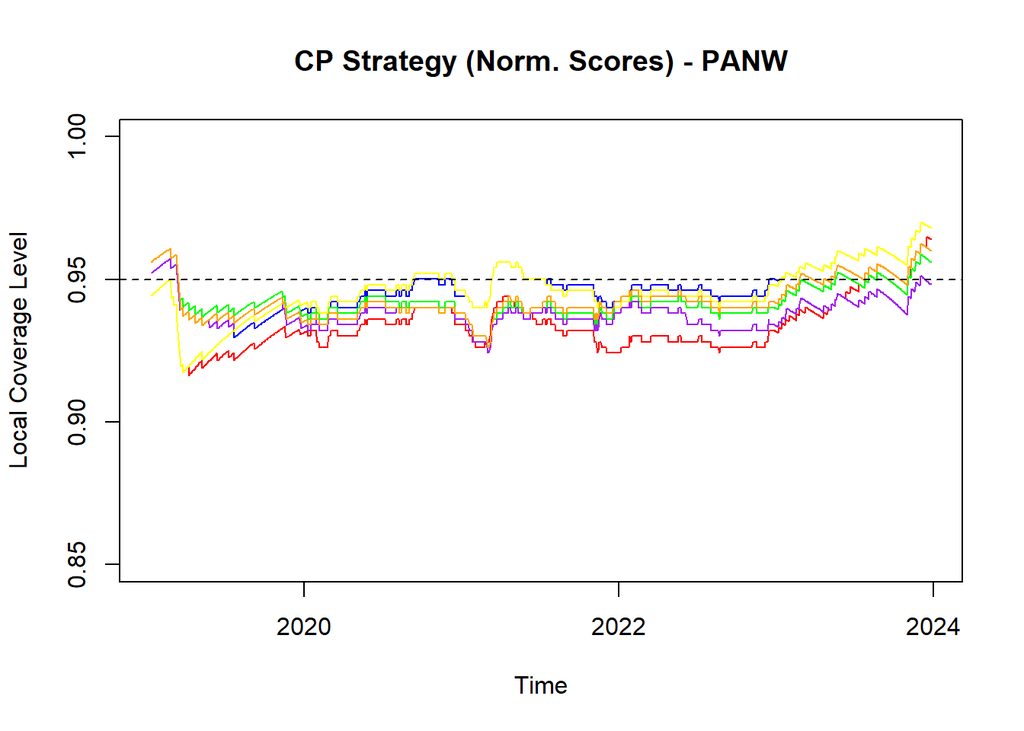

```r
# Comparative Graph Normalized Scores
plot(date, localCov_adaptive_garch, type = "l", col = "blue", ylim = c(0.85, 1),
     main = "CP Strategy (Norm. Scores) - PANW",
     xlab = "Time", ylab = "Local Coverage Level")
lines(date, localCov_standard_garch, col = "red")
lines(date, localCov_adaptive_egarch, col = "green")
lines(date, localCov_standard_egarch, col = "purple")
lines(date, localCov_adaptive_garch_mom, col = "yellow")
lines(date, localCov_adaptive_egarch_mom, col = "orange")
abline(h = 0.95, col = "black", lty = 2)  # Target level 1 - alpha
```

```r
# Let's compare the local coverage rates also with the simple scores
######################################################

# Apply Standard CP - GARCH(1,1) Simple Scores
results_standard_garch_simple <- garchCF(
  returns = returns,
  alpha = 0.05,
  lookback = 1250,
  garchP = 1,
  garchQ = 1,
  startUp = 100,
  verbose = FALSE
)
```

```
## [1] "Done 1300 steps"
## [1] "Done 1400 steps"
## [1] "Done 1500 steps"
## [1] "Done 1600 steps"
## [1] "Done 1700 steps"
## [1] "Done 1800 steps"
## [1] "Done 1900 steps"
## [1] "Done 2000 steps"
## [1] "Done 2100 steps"
## [1] "Done 2200 steps"
## [1] "Done 2300 steps"
## [1] "Done 2400 steps"
```

```r
errSeq_standard_garch_simple <- results_standard_garch_simple$errSeq
localCov_standard_garch_simple <- calculateLocalCov(errSeq_standard_garch_simple, windowSize = 500)


# Apply Standard CP - EGARCH Simple Scores
results_standard_egarch_simple <- EgarchCF(
  returns = returns,
  alpha = 0.05,
  lookback = 1250,
  garchP = 1,
  garchQ = 1,
  startUp = 100,
  verbose = FALSE
)
```

```
## [1] "Done 1300 steps"
## [1] "Done 1400 steps"
## [1] "Done 1500 steps"
## [1] "Done 1600 steps"
## [1] "Done 1700 steps"
## [1] "Done 1800 steps"
## [1] "Done 1900 steps"
## [1] "Done 2000 steps"
## [1] "Done 2100 steps"
## [1] "Done 2200 steps"
## [1] "Done 2300 steps"
## [1] "Done 2400 steps"
```

```r
errSeq_standard_egarch_simple <- results_standard_egarch_simple$errSeq
localCov_standard_egarch_simple <- calculateLocalCov(errSeq_standard_egarch_simple, windowSize = 500)


# Apply Adaptive CP (Simple) - GARCH(1,1) Simple Scores
results_adaptive_garch_simple <- AdaptivegarchCF(
  returns = returns,
  alpha = 0.05,
  gamma = 0.001,
  lookback = 1250,
  garchP = 1,
  garchQ = 1,
  startUp = 100,
  verbose = FALSE
)
```

```
## [1] "Done 1300 steps"
## [1] "Done 1400 steps"
## [1] "Done 1500 steps"
## [1] "Done 1600 steps"
## [1] "Done 1700 steps"
## [1] "Done 1800 steps"
## [1] "Done 1900 steps"
## [1] "Done 2000 steps"
## [1] "Done 2100 steps"
## [1] "Done 2200 steps"
## [1] "Done 2300 steps"
## [1] "Done 2400 steps"
```

```r
errSeq_adaptive_garch_simple <- results_adaptive_garch_simple$errSeq
localCov_adaptive_garch_simple <- calculateLocalCov(errSeq_adaptive_garch_simple, windowSize = 500)

# Apply Adaptive CP (Simple) - EGARCH Simple Scores
results_adaptive_egarch_simple <- AdaptiveEgarchCF(
  returns = returns,
  alpha = 0.05,
  gamma = 0.001,
  lookback = 1250,
  garchP = 1,
  garchQ = 1,
  startUp = 100,
  verbose = FALSE
)
```

```
## [1] "Done 1300 steps"
## [1] "Done 1400 steps"
## [1] "Done 1500 steps"
## [1] "Done 1600 steps"
## [1] "Done 1700 steps"
## [1] "Done 1800 steps"
## [1] "Done 1900 steps"
## [1] "Done 2000 steps"
## [1] "Done 2100 steps"
## [1] "Done 2200 steps"
## [1] "Done 2300 steps"
## [1] "Done 2400 steps"
```

```r
errSeq_adaptive_egarch_simple <- results_adaptive_egarch_simple$errSeq
localCov_adaptive_egarch_simple <- calculateLocalCov(errSeq_adaptive_egarch_simple, windowSize = 500)
```

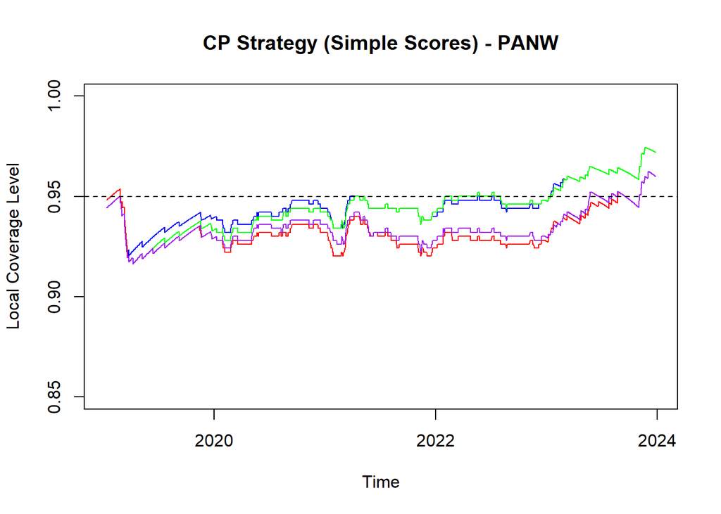

```r
# Comparative Graph Simple Scores
plot(date, localCov_adaptive_garch_simple, type = "l", col = "blue", ylim = c(0.85, 1),
     main = "CP Strategy (Simple Scores) - PANW",
     xlab = "Time", ylab = "Local Coverage Level")
lines(date, localCov_standard_garch_simple, col = "red")
lines(date, localCov_adaptive_egarch_simple, col = "green")
lines(date, localCov_standard_egarch_simple, col = "purple")
abline(h = 0.95, col = "black", lty = 2)  # Target level 1 - alpha
```

### **Conclusion**

- **Green (Adaptive Alpha EGARCH)** is the most effective strategy, achieving the best balance of stability and responsiveness to market conditions.
- **Blue (Adaptive Alpha GARCH)** also performs well but is less robust compared to Green.
- **Red (Standard CP GARCH)** and **Purple (Standard CP EGARCH)** serve as stable baselines but fail to adapt adequately during market turbulence, with Purple outperforming Red slightly.

This analysis emphasizes the importance of adaptiveness and advanced volatility modeling for maintaining the desired coverage level in financial applications.

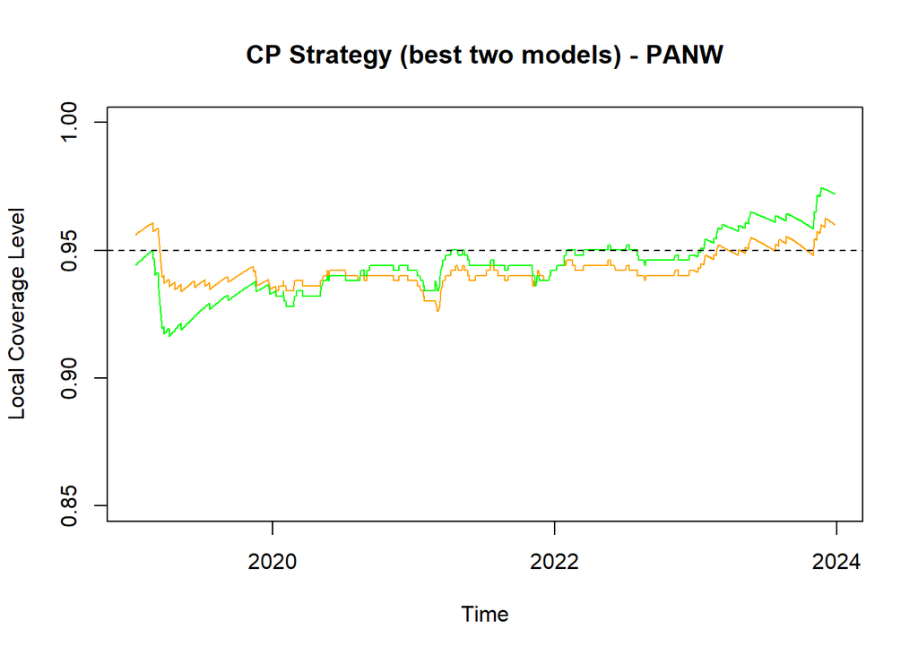

```r
# Comparative graph between Adaptive Momentum EGARCH (normalized scores) and Adaptive simple EGARCH (simple scores)
plot(date, localCov_adaptive_egarch_mom, type = "l", col = "orange", ylim = c(0.85, 1),
     main = "CP Strategy (best two models) - PANW",
     xlab = "Time", ylab = "Local Coverage Level")
lines(date, localCov_adaptive_egarch_simple, col = "green")
abline(h = 0.95, col = "black", lty = 2)
```

### Interpretation of the Graph: CP Strategy (Best Two Models) - PANW

### **Observations**

#### **Green Line (Adaptive Simple EGARCH)**:

- The green line also performs well, but it shows more noticeable deviations from the **0.95** target in some periods.
- It is less responsive compared to the orange line, as it struggles to align as closely with the target during certain market conditions.

## These larger and more frequent deviations below the target level suggest that it lacks the precision required in volatile scenarios.

```r
## Evaluate the impact of the adaptation rate, by choosing some different values, on the ACI
## procedure and comment your results (see also Section 2.1)

#### ACI SIMPLE eGARCH (simple scores) gamma1=0,001
# Apply Adaptive CP (Simple) - EGARCH Simple Scores
results_adaptive_egarch_simple_gamma1 <- AdaptiveEgarchCF(
  returns = returns,
  alpha = 0.05,
  gamma = 0.001,
  lookback = 1250,
  garchP = 1,
  garchQ = 1,
  startUp = 100,
  verbose = FALSE
)
```

```
## [1] "Done 1300 steps"
## [1] "Done 1400 steps"
## [1] "Done 1500 steps"
## [1] "Done 1600 steps"
## [1] "Done 1700 steps"
## [1] "Done 1800 steps"
## [1] "Done 1900 steps"
## [1] "Done 2000 steps"
## [1] "Done 2100 steps"
## [1] "Done 2200 steps"
## [1] "Done 2300 steps"
## [1] "Done 2400 steps"
```

```r
errSeq_adaptive_egarch_simple_gamma1 <- results_adaptive_egarch_simple_gamma1$errSeq
localCov_adaptive_egarch_simple_gamma1 <- calculateLocalCov(errSeq_adaptive_egarch_simple_gamma1, windowSize = 500)

#### ACI SIMPLE eGARCH (simple scores) gamma2=0,01
# Apply Adaptive CP (Simple) - EGARCH Simple Scores
results_adaptive_egarch_simple_gamma2 <- AdaptiveEgarchCF(
  returns = returns,
  alpha = 0.05,
  gamma = 0.01,
  lookback = 1250,
  garchP = 1,
  garchQ = 1,
  startUp = 100,
  verbose = FALSE
)
```

```
## [1] "Done 1300 steps"
## [1] "Done 1400 steps"
## [1] "Done 1500 steps"
## [1] "Done 1600 steps"
## [1] "Done 1700 steps"
## [1] "Done 1800 steps"
## [1] "Done 1900 steps"
## [1] "Done 2000 steps"
## [1] "Done 2100 steps"
## [1] "Done 2200 steps"
## [1] "Done 2300 steps"
## [1] "Done 2400 steps"
```

```r
errSeq_adaptive_egarch_simple_gamma2 <- results_adaptive_egarch_simple_gamma2$errSeq
localCov_adaptive_egarch_simple_gamma2 <- calculateLocalCov(errSeq_adaptive_egarch_simple_gamma2, windowSize = 500)

#### ACI SIMPLE eGARCH (simple scores) gamma3=0,05
# Apply Adaptive CP (Simple) - EGARCH Simple Scores
results_adaptive_egarch_simple_gamma3 <- AdaptiveEgarchCF(
  returns = returns,
  alpha = 0.05,
  gamma = 0.05,
  lookback = 1250,
  garchP = 1,
  garchQ = 1,
  startUp = 100,
  verbose = FALSE
)
```

```
## [1] "Done 1300 steps"
## [1] "Done 1400 steps"
## [1] "Done 1500 steps"
## [1] "Done 1600 steps"
## [1] "Done 1700 steps"
## [1] "Done 1800 steps"
## [1] "Done 1900 steps"
## [1] "Done 2000 steps"
## [1] "Done 2100 steps"
## [1] "Done 2200 steps"
## [1] "Done 2300 steps"
## [1] "Done 2400 steps"
```

```r
errSeq_adaptive_egarch_simple_gamma3 <- results_adaptive_egarch_simple_gamma3$errSeq
localCov_adaptive_egarch_simple_gamma3 <- calculateLocalCov(errSeq_adaptive_egarch_simple_gamma3, windowSize = 500)
```

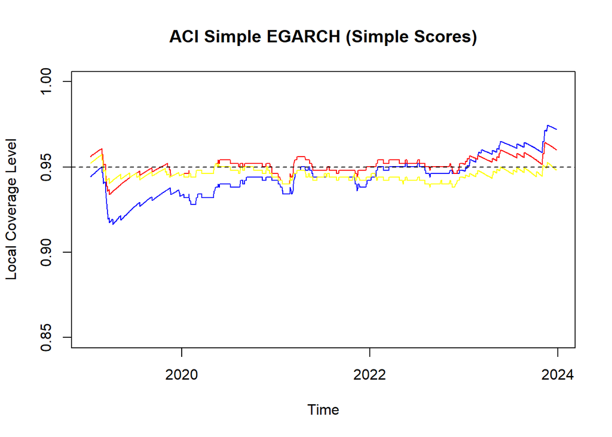

```r
# Comparative graph between ACI SIMPLE EGARCH with different gamma values
plot(date, localCov_adaptive_egarch_simple_gamma1, type = "l", col = "blue", ylim = c(0.85, 1),
     main = "ACI Simple EGARCH (Simple Scores)",
     xlab = "Time", ylab = "Local Coverage Level")
lines(date, localCov_adaptive_egarch_simple_gamma2, col = "red")
lines(date, localCov_adaptive_egarch_simple_gamma3, col = "yellow")
abline(h = 0.95, col = "black", lty = 2)
```

### Interprgammation of the Graph: ACI Simple EGARCH with Different Gamma Values

### **Conclusion**

- **Gamma = 0.01 (Red)** provides the best overall performance, balancing stability and responsiveness to maintain the target coverage level.
- **Gamma = 0.05 (Yellow)** is suitable for highly dynamic environments but may overreact to smaller fluctuations.
- **Gamma = 0.001 (Blue)** is reliable in calm markets but underperforms in volatile conditions due to its slow responsiveness.

This analysis highlights the impact of gamma values on model performance, emphasizing the need to select an appropriate gamma based on market conditions and desired adaptiveness.

```r
# Apply Adaptive CP MOMENTUM - EGARCH(1,1) Normalized Scores

#### ACI MOMENTUM EGARCH (NORM scores) gamma1=0,001
results_adaptive_egarch_mom_gamma1 <- MomAdaptiveNormEgarchCF(
  returns = returns,
  alpha = 0.05,
  gamma = 0.001,
  lookback = 1250,
  garchP = 1,
  garchQ = 1,
  startUp = 100,
  verbose = FALSE
)
```

```
## [1] "Done 1300 steps"
## [1] "Done 1400 steps"
## [1] "Done 1500 steps"
## [1] "Done 1600 steps"
## [1] "Done 1700 steps"
## [1] "Done 1800 steps"
## [1] "Done 1900 steps"
## [1] "Done 2000 steps"
## [1] "Done 2100 steps"
## [1] "Done 2200 steps"
## [1] "Done 2300 steps"
## [1] "Done 2400 steps"
```

```r
errSeq_adaptive_egarch_mom_gamma1 <- results_adaptive_egarch_mom_gamma1$errSeq


localCov_adaptive_egarch_mom_gamma1 <- calculateLocalCov(errSeq_adaptive_egarch_mom_gamma1, windowSize = 500)

#### ACI MOMENTUM EGARCH (NORM scores) gamma2=0,01
results_adaptive_egarch_mom_gamma2 <- MomAdaptiveNormEgarchCF(
  returns = returns,
  alpha = 0.05,
  gamma = 0.01,
  lookback = 1250,
  garchP = 1,
  garchQ = 1,
  startUp = 100,
  verbose = FALSE
)
```

```
## [1] "Done 1300 steps"
## [1] "Done 1400 steps"
## [1] "Done 1500 steps"
## [1] "Done 1600 steps"
## [1] "Done 1700 steps"
## [1] "Done 1800 steps"
## [1] "Done 1900 steps"
## [1] "Done 2000 steps"
## [1] "Done 2100 steps"
## [1] "Done 2200 steps"
## [1] "Done 2300 steps"
## [1] "Done 2400 steps"
```

```r
errSeq_adaptive_egarch_mom_gamma2 <- results_adaptive_egarch_mom_gamma2$errSeq

localCov_adaptive_egarch_mom_gamma2 <- calculateLocalCov(errSeq_adaptive_egarch_mom_gamma2, windowSize = 500)

#### ACI MOMENTUM EGARCH (NORM scores) gamma3=0,05
results_adaptive_egarch_mom_gamma3 <- MomAdaptiveNormEgarchCF(
  returns = returns,
  alpha = 0.05,
  gamma = 0.05,
  lookback = 1250,
  garchP = 1,
  garchQ = 1,
  startUp = 100,
  verbose = FALSE
)
```

```
## [1] "Done 1300 steps"
## [1] "Done 1400 steps"
## [1] "Done 1500 steps"
## [1] "Done 1600 steps"
## [1] "Done 1700 steps"
## [1] "Done 1800 steps"
## [1] "Done 1900 steps"
## [1] "Done 2000 steps"
## [1] "Done 2100 steps"
## [1] "Done 2200 steps"
## [1] "Done 2300 steps"
## [1] "Done 2400 steps"
```

```r
errSeq_adaptive_egarch_mom_gamma3 <- results_adaptive_egarch_mom_gamma3$errSeq

localCov_adaptive_egarch_mom_gamma3 <- calculateLocalCov(errSeq_adaptive_egarch_mom_gamma3, windowSize = 500)
```

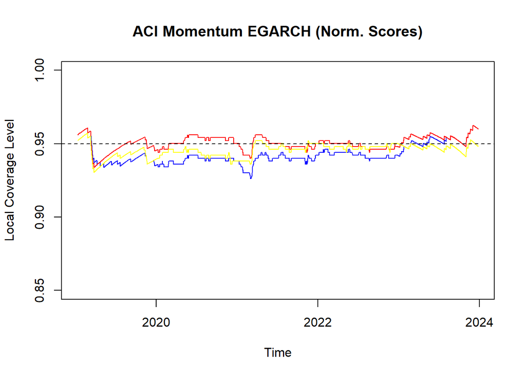

```r
# Comparative Graph of ACI MOMENTUM EGARCH with NORMALIZED SCORES
plot(date, localCov_adaptive_egarch_mom_gamma1, type = "l", col = "blue", ylim = c(0.85, 1),
     main = "ACI Momentum EGARCH (Norm. Scores)",
     xlab = "Time", ylab = "Local Coverage Level")
lines(date, localCov_adaptive_egarch_mom_gamma2, col = "red")
lines(date, localCov_adaptive_egarch_mom_gamma3, col = "yellow")
abline(h = 0.95, col = "black", lty = 2)
```

### Interprgammation of the Graph: ACI Momentum EGARCH with Normalized Scores

### **Comparison Between Strategies**

1. **Stability**:
   - **Blue (Gamma = 0.001)** is the most stable but struggles to adapt during periods of significant market changes.
2. **Adaptability**:
   - **Yellow (Gamma = 0.05)** is the most adaptive but prone to over-adjustments, resulting in fluctuations around the target level.
3. **Balanced Performance**:
   - **Red (Gamma = 0.01)** achieves the best trade-off between stability and responsiveness, maintaining consistent alignment with the **0.95** target.

### **Conclusion**

- **Gamma = 0.01 (Red)** is the most effective choice, balancing stability and responsiveness to maintain the target coverage level.
- **Gamma = 0.05 (Yellow)** excels in highly dynamic environments but risks overshooting or undershooting the target.
- **Gamma = 0.001 (Blue)** is reliable in calm markets but underperforms in volatile conditions due to its slow responsiveness.

This analysis underscores the importance of selecting an appropriate gamma value based on the specific market environment and desired level of adaptability.

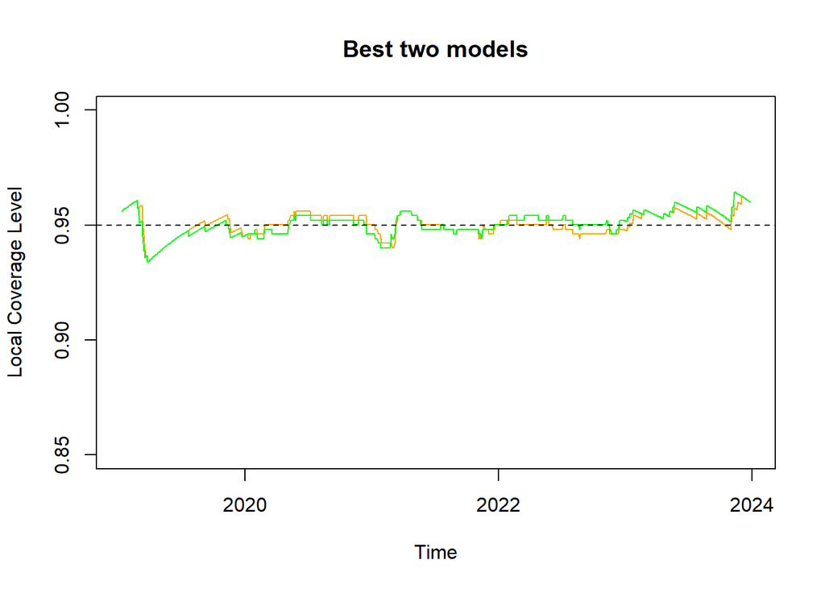

```r
# Comparison graph between the best two models
plot(date, localCov_adaptive_egarch_mom_gamma2, type = "l", col = "orange", ylim = c(0.85, 1),
     main = "Best two models",
     xlab = "Time", ylab = "Local Coverage Level")
lines(date, localCov_adaptive_egarch_simple_gamma2, col = "green")
abline(h = 0.95, col = "black", lty = 2)
```

# **PART II**

1. Adaptive Conformal Inference (ACI) is designed to adapt to temporal distribution shifts in time series.

The idea behind ACI is twofold. Firstly, it considers an online procedure with a random partitioning of data into training and calibration sets.

Secondly, to improve adaptation when the data is heavily shifted, it uses an effective coverage level $\alpha_t$, updated recursively, instead of the target level $\alpha$.

The update is defined as:

$$\alpha_{t+1}
= \alpha_t + \gamma \left( \alpha - {1}\{y_t \notin
\mathcal{C}_{\alpha_t}(x_t)\} \right),$$
where $\gamma$ is a learning rate parameter that controls how quickly $\alpha_t$ adapts to observed coverage.

If ACI fails to cover at time $t$, then $\alpha_{t+1} \leq \alpha_t$ and the size of the prediction interval increases; conversely, when it covers.

The choice of $\gamma$ is crucial for ACI’s performance. A high $\gamma$ makes the method more adaptive to observed distribution shifts, but can also lead to instability and infinite prediction intervals.

To overcome the challenge of choosing an optimal $\gamma$ value, the authors propose Aggregated Adaptive Conformal Inference (AgACI), which is based on aggregating online experts.

AgACI runs ACI for $K$ different $\gamma$ values, $\{\gamma_k\}_{k \leq K}$, chosen by the user.

At each time step $t$, AgACI aggregates the prediction intervals produced by the $K$ ACI experts, $\mathcal{C}{\alpha_t,k}( \cdot ) = [\hat{b}{\ell,t,k}(\cdot), \hat{b}{u,t,k}(\cdot)]$, one for each bound, and produces an aggregated prediction interval $\tilde{C}_t( \cdot ) = [\tilde{b}{\ell,t}(\cdot), \tilde{b}_{u,t}(\cdot)]$.

The aggregation is performed using an online aggregation rule, like Bernstein Online Aggregation (BOA).

BOA assigns weights to the experts based on their past performance, measured by the pinball loss function.

These weights are used to compute a weighted average of the expert prediction intervals, producing the aggregated prediction interval.

In summary, AgACI is a parameter-free adaptive prediction interval method that aggregates online experts to handle distribution shifts and temporal dependence in time series. This makes AgACI a potentially valuable tool for real-world applications where stationarity cannot be guaranteed.

```r
library(quantmod)
library(rugarch)
library(opera)
```

```r
library(dplyr)

agaciVolatilityForecasting <- function(returns, alpha = 0.05,
                                       gammaGrid = seq(0.001, 0.01, by = 0.001),
                                       lookback = 1250, garchP = 1, garchQ = 1,
                                       startUp = 100, verbose = FALSE,
                                       updateMethod = "Momentum", momentumBW = 0.95) {
  myT <- length(returns)
  T0 <- max(startUp, lookback)


  garchSpec <- ugarchspec(
    mean.model = list(armaOrder = c(0, 0), include.mean = FALSE),
    variance.model = list(model = "sGARCH", garchOrder = c(garchP, garchQ)),
    distribution.model = "norm"
  )

  # Initialize storage variables
  K <- length(gammaGrid)  # number of 'experts'
  Tlen <- myT - T0

  # Vector to save the GARCH prediction (variance) at each step
  garchForecastVec <- rep(NA, Tlen)

  scores          <- array(NA, dim = Tlen)
  alphaSeq        <- matrix(alpha, nrow = K, ncol = Tlen)

  alphaSeq2       <- rep(alpha, Tlen)  # basic alpha for the BOA part

  errSeqOC        <- matrix(NA, nrow = K, ncol = Tlen)  # Matrix for the errors of each expert
  aggregatedalpha <- rep(NA, Tlen)
  err             <- rep(NA, Tlen)  # Vector for errors per aggregate

  lower_limit <- 0.001
  upper_limit <- 0.999


  # === 1) Calculating forecasts with ACI logic ===
  for (t in T0:(myT - 1)) {

    # Fit GARCH and forecast
    garchFit     <- ugarchfit(garchSpec, returns[(t - lookback + 1):(t - 1)], solver = "hybrid")
    sigmaNext    <- sigma(ugarchforecast(garchFit, n.ahead = 1))
    garchForecast <- sigmaNext^2  # GARCH Forecast

    colIdx <- t - T0 + 1

    # Save GARCH prediction
    garchForecastVec[colIdx] <- garchForecast

    # Conformity score
    scores[colIdx] <- abs(returns[t]^2 - sigmaNext^2) / sigmaNext^2

    # Historical scores
    historical <- scores[max(1, colIdx - lookback + 1):(colIdx - 1)]

    # Threshold calculation and alpha update for each expert
    for (g in seq_along(gammaGrid)) {
      gamma <- gammaGrid[g]

      if (t == T0) {
        thr <- quantile(historical, 1 - alpha)
        errSeqOC[g, colIdx] <- as.numeric(scores[colIdx] > thr)


      } else {
        thr <- quantile(historical, 1 - alphaSeq[g, colIdx - 1])
        errSeqOC[g, colIdx] <- as.numeric(scores[colIdx] > thr)


        # alphaSeq Update
        if (updateMethod == "Simple") {
          alphaSeq[g, colIdx] <- alphaSeq[g, colIdx - 1] + gamma * (alpha - errSeqOC[g, colIdx])

        } else if (updateMethod == "Momentum") {
          w <- rev(momentumBW^(1:(colIdx - 1)))
          w <- w / sum(w)
          alphaSeq[g, colIdx] <- alphaSeq[g, colIdx - 1] + gamma * (alpha - sum(errSeqOC[g, colIdx] * w))
        }

        # Clipping
        alphaSeq[g, colIdx] <- min(upper_limit, max(lower_limit, alphaSeq[g, colIdx]))
      }
    }
  }

  # Cumulative average per column
  cummean_cols <- apply(errSeqOC, 2, cummean)


  # === 2) Aggregation with BOA ===
  aggalpha <- mixture(
    Y       = alphaSeq2,
    experts = t(cummean_cols),
    model   = "BOA",
    loss.gradient = TRUE,
    loss.type = 'square'
  )

  print(aggalpha$weights)

  # Converts weights into a data frame for readable output
  weights_df <- as.data.frame(aggalpha$weights)
  colnames(weights_df) <- paste0("Expert_", 1:K)
  rownames(weights_df) <- paste0("T", 1:nrow(weights_df))

  # Print neatly
  print(head(weights_df, 10))  # Show first 10 lines as an example

  # Aggregate calculation and err vector for the aggregate
  for (t in T0:(myT - 1)) {
    colIdx <- t - T0 + 1

    historical <- scores[max(1, colIdx - lookback + 1):(colIdx - 1)]

    if (colIdx == 1) {
      aggregatedalpha[colIdx] <- alpha
      thr <- quantile(historical, 1 - aggregatedalpha[colIdx])

      err[colIdx] <- as.numeric(scores[colIdx] > thr)

    } else {
      w_t <- aggalpha$weights[colIdx - 1, ]
      aggregatedalpha[colIdx] <- sum(w_t * alphaSeq[, colIdx])

      thr <- quantile(historical, 1 - aggregatedalpha[colIdx])

      err[colIdx] <- as.numeric(scores[colIdx] > thr)
    }
  }


  # Returning the results
  return(list(
    aggregatedalpha           = aggregatedalpha,
    err                       = err,
    errSeqOC                  = errSeqOC,
    garchForecastVec          = garchForecastVec,
    alphaSeq                  = alphaSeq,
    scores                    = scores,
    weights_df                = weights_df))

}
```